# M6L4_Assignment

Xueyi Fan

June 30, 2016

# Assignment:

1. Go to the UC Irvine Machine Learning Repository and find a dataset for supervised classification. Every student MUST use a different dataset so you MUST get approved for which you can going to use. This can be the same dataset you used for the unsupervised clustering as long as the data has some labeled data.
2. Classify your data using Linear Discriminant Analysis (LDA). Answer the following questions:
- Does the number of predictor variables for LDA make a difference? Try for a range of models using differing numbers of predictor variables.
- What determines the number of linear discriminants in LDA.
- Does scaling, normalization or leaving the data unscaled make a difference for LDA?

```r
library("ggplot2")
library("MASS")
library("car")
```

# Answer:

## Loading my data

Here, I choose the [Breast Cancer Wisconsin (Diagnostic) data set](https://archive.ics.uci.edu/ml/machine-learning-databases/breast-cancer-wisconsin/)

```r
data_url <- 'https://archive.ics.uci.edu/ml/machine-learning-databases/breast-cancer-wisconsin/wdbc.data'

data <- read.table(url(data_url), sep = ',')

names(data) <- c('ID number', 'Diagnosis','radius_mean','texure_mean','perimeter_mean','area_mean','smoothness_mean','compactness_mean','concavity_mean','concave_points_mean','symmetry_mean','fractal_dimension_mean', 'radius_SE','texure_SE','perimeter_SE','area_SE','smoothness_SE','compactness_SE','concavity_SE','concave_points_SE','symmetry_SE','fractal_dimension_SE','radius_worst','texure_worst','perimeter_worst','area_worst','smoothness_worst','compactness_worst','concavity_worst','concave_points_worst','symmetry_worst','fractal_dimension_worst')

head(data)
```

```
##   ID number Diagnosis radius_mean texure_mean perimeter_mean area_mean
## 1    842302         M       17.99       10.38         122.80    1001.0
## 2    842517         M       20.57       17.77         132.90    1326.0
## 3  84300903         M       19.69       21.25         130.00    1203.0
## 4  84348301         M       11.42       20.38          77.58     386.1
## 5  84358402         M       20.29       14.34         135.10    1297.0
## 6    843786         M       12.45       15.70          82.57     477.1
##   smoothness_mean compactness_mean concavity_mean concave_points_mean
## 1         0.11840          0.27760         0.3001             0.14710
## 2         0.08474          0.07864         0.0869             0.07017
## 3         0.10960          0.15990         0.1974             0.12790
## 4         0.14250          0.28390         0.2414             0.10520
## 5         0.10030          0.13280         0.1980             0.10430
## 6         0.12780          0.17000         0.1578             0.08089
##   symmetry_mean fractal_dimension_mean radius_SE texure_SE perimeter_SE
```

[output cut: 41 more lines]

```r
str(data)
```

```
## 'data.frame':    569 obs. of  32 variables:
##  $ ID number              : int  842302 842517 84300903 84348301 84358402 843786 844359 84458202 844981 84501001 ...
##  $ Diagnosis              : Factor w/ 2 levels "B","M": 2 2 2 2 2 2 2 2 2 2 ...
##  $ radius_mean            : num  18 20.6 19.7 11.4 20.3 ...
##  $ texure_mean            : num  10.4 17.8 21.2 20.4 14.3 ...
##  $ perimeter_mean         : num  122.8 132.9 130 77.6 135.1 ...
##  $ area_mean              : num  1001 1326 1203 386 1297 ...
##  $ smoothness_mean        : num  0.1184 0.0847 0.1096 0.1425 0.1003 ...
##  $ compactness_mean       : num  0.2776 0.0786 0.1599 0.2839 0.1328 ...
##  $ concavity_mean         : num  0.3001 0.0869 0.1974 0.2414 0.198 ...
##  $ concave_points_mean    : num  0.1471 0.0702 0.1279 0.1052 0.1043 ...
##  $ symmetry_mean          : num  0.242 0.181 0.207 0.26 0.181 ...
##  $ fractal_dimension_mean : num  0.0787 0.0567 0.06 0.0974 0.0588 ...
##  $ radius_SE              : num  1.095 0.543 0.746 0.496 0.757 ...
##  $ texure_SE              : num  0.905 0.734 0.787 1.156 0.781 ...
```

[output cut: 18 more lines]

```r
summary(data)
```

```
##    ID number         Diagnosis  radius_mean      texure_mean
##  Min.   :     8670   B:357     Min.   : 6.981   Min.   : 9.71
##  1st Qu.:   869218   M:212     1st Qu.:11.700   1st Qu.:16.17
##  Median :   906024             Median :13.370   Median :18.84
##  Mean   : 30371831             Mean   :14.127   Mean   :19.29
##  3rd Qu.:  8813129             3rd Qu.:15.780   3rd Qu.:21.80
##  Max.   :911320502             Max.   :28.110   Max.   :39.28
##  perimeter_mean     area_mean      smoothness_mean   compactness_mean
##  Min.   : 43.79   Min.   : 143.5   Min.   :0.05263   Min.   :0.01938
##  1st Qu.: 75.17   1st Qu.: 420.3   1st Qu.:0.08637   1st Qu.:0.06492
##  Median : 86.24   Median : 551.1   Median :0.09587   Median :0.09263
##  Mean   : 91.97   Mean   : 654.9   Mean   :0.09636   Mean   :0.10434
##  3rd Qu.:104.10   3rd Qu.: 782.7   3rd Qu.:0.10530   3rd Qu.:0.13040
##  Max.   :188.50   Max.   :2501.0   Max.   :0.16340   Max.   :0.34540
##  concavity_mean    concave_points_mean symmetry_mean
##  Min.   :0.00000   Min.   :0.00000     Min.   :0.1060
##  1st Qu.:0.02956   1st Qu.:0.02031     1st Qu.:0.1619
##  Median :0.06154   Median :0.03350     Median :0.1792
##  Mean   :0.08880   Mean   :0.04892     Mean   :0.1812
##  3rd Qu.:0.13070   3rd Qu.:0.07400     3rd Qu.:0.1957
##  Max.   :0.42680   Max.   :0.20120     Max.   :0.3040
##  fractal_dimension_mean   radius_SE        texure_SE       perimeter_SE
##  Min.   :0.04996        Min.   :0.1115   Min.   :0.3602   Min.   : 0.757
##  1st Qu.:0.05770        1st Qu.:0.2324   1st Qu.:0.8339   1st Qu.: 1.606
##  Median :0.06154        Median :0.3242   Median :1.1080   Median : 2.287
##  Mean   :0.06280        Mean   :0.4052   Mean   :1.2169   Mean   : 2.866
##  3rd Qu.:0.06612        3rd Qu.:0.4789   3rd Qu.:1.4740   3rd Qu.: 3.357
##  Max.   :0.09744        Max.   :2.8730   Max.   :4.8850   Max.   :21.980
##     area_SE        smoothness_SE      compactness_SE      concavity_SE
##  Min.   :  6.802   Min.   :0.001713   Min.   :0.002252   Min.   :0.00000
##  1st Qu.: 17.850   1st Qu.:0.005169   1st Qu.:0.013080   1st Qu.:0.01509
##  Median : 24.530   Median :0.006380   Median :0.020450   Median :0.02589
##  Mean   : 40.337   Mean   :0.007041   Mean   :0.025478   Mean   :0.03189
##  3rd Qu.: 45.190   3rd Qu.:0.008146   3rd Qu.:0.032450   3rd Qu.:0.04205
##  Max.   :542.200   Max.   :0.031130   Max.   :0.135400   Max.   :0.39600
##  concave_points_SE   symmetry_SE       fractal_dimension_SE
##  Min.   :0.000000   Min.   :0.007882   Min.   :0.0008948
##  1st Qu.:0.007638   1st Qu.:0.015160   1st Qu.:0.0022480
##  Median :0.010930   Median :0.018730   Median :0.0031870
##  Mean   :0.011796   Mean   :0.020542   Mean   :0.0037949
```

[output cut: 8 more lines]

```
##  Max.   :36.04   Max.   :49.54   Max.   :251.20   Max.   :4254.0
##  smoothness_worst  compactness_worst concavity_worst  concave_points_worst
##  Min.   :0.07117   Min.   :0.02729   Min.   :0.0000   Min.   :0.00000
##  1st Qu.:0.11660   1st Qu.:0.14720   1st Qu.:0.1145   1st Qu.:0.06493
##  Median :0.13130   Median :0.21190   Median :0.2267   Median :0.09993
##  Mean   :0.13237   Mean   :0.25427   Mean   :0.2722   Mean   :0.11461
##  3rd Qu.:0.14600   3rd Qu.:0.33910   3rd Qu.:0.3829   3rd Qu.:0.16140
##  Max.   :0.22260   Max.   :1.05800   Max.   :1.2520   Max.   :0.29100
##  symmetry_worst   fractal_dimension_worst
##  Min.   :0.1565   Min.   :0.05504
##  1st Qu.:0.2504   1st Qu.:0.07146
##  Median :0.2822   Median :0.08004
##  Mean   :0.2901   Mean   :0.08395
##  3rd Qu.:0.3179   3rd Qu.:0.09208
##  Max.   :0.6638   Max.   :0.20750
```

```r
#shuffle the data
set.seed(123)
cancer_data <- data[order(runif(nrow(data))),]
cancer_data[,2]
```

```
##   [1] B M B B B B B B B M B B B B B B M M B M B B B B B B B M B B B B B M B
##  [36] B M B B B B M B B B B B B B B B B M M B B B B B B B B M B M B B B B B
##  [71] M B B M B B B B M M M B M B B B B M B B B M B B B B B B M B B M B B M
## [106] M M B B B M B B M B B B B B M M B M M B B B B M B B B M B M B B B B M
## [141] B B B M B B M B B M B B M B B M B B B M B B B M M M M B B B B B B M B
## [176] B B B M B M B B M M M B M B B B M M B B M M M B B B M M M B B M B B M
## [211] B B B M B M M B B B B B B B M B B B B B B B M B B B M B B B M M M M B
## [246] M M M M M M B M B M B B B M M B B B B B B M B B M M M M M B B B M M B
## [281] B M B M B B B B M B M B B B B M B B B B B B M M M M B M B B M B M B M
## [316] B B B B B B M B B B B M B M B B B M M M B M B M B B M B M M M B M M B
## [351] M M M B M B M B B B B B B B B M M B B B B M M M M M B M M B B B B B B
## [386] B B M M M M M M B B M M B B M M B B B B M B M M B M M B M B B B M B B
## [421] B B B B M B B M B B B B M B M B M M M B B M M M B M B M M M M B M M M
## [456] B M B B B B B M B B B M B B M B M B M B B B B M B B M B B M B B B B B
## [491] B M B M M M M B B M B M M B B B B M B M M M B B M B M B B B M B M M M
## [526] M B B B M B M B B M B M M B B M B M M B B B M B M B B M B M M B B B M
## [561] B B M B B B M M B
## Levels: B M
```

## Classify my data using Linear Discriminant Analysis (LDA)

```r
#to normalize data
normalize <- function(x){
  return((x-min(x))/(max(x)-min(x)))
}
cancer.normalized <- as.data.frame(lapply(cancer_data[,3:32],normalize))
head(cancer.normalized)
```

```
##   radius_mean texure_mean perimeter_mean  area_mean smoothness_mean
## 1  0.32746462   0.2336828     0.31221063 0.19338282       0.1412837
## 2  0.32273179   0.2056138     0.32229977 0.18689290       0.4339623
## 3  0.20393772   0.1126141     0.19653099 0.10371156       0.4126569
## 4  0.09555587   0.1586067     0.08686338 0.04360551       0.1572628
## 5  0.25931185   0.3442678     0.25319605 0.13904560       0.2878036
## 6  0.21056368   0.2570172     0.20641283 0.10795334       0.5106978
##   compactness_mean concavity_mean concave_points_mean symmetry_mean
## 1       0.10370529    0.052108716          0.06655070     0.3803030
## 2       0.33316974    0.182497657          0.25193837     0.3040404
## 3       0.17391571    0.076499531          0.13692843     0.3580808
## 4       0.03613275    0.008624649          0.01725646     0.3676768
## 5       0.25157966    0.160028116          0.15402584     0.3641414
## 6       0.23151954    0.047586692          0.09249503     0.2954545
##   fractal_dimension_mean  radius_SE  texure_SE perimeter_SE     area_SE
```

[output cut: 34 more lines]

```r
summary(cancer.normalized)
```

```
##   radius_mean      texure_mean     perimeter_mean     area_mean
##  Min.   :0.0000   Min.   :0.0000   Min.   :0.0000   Min.   :0.0000
##  1st Qu.:0.2233   1st Qu.:0.2185   1st Qu.:0.2168   1st Qu.:0.1174
##  Median :0.3024   Median :0.3088   Median :0.2933   Median :0.1729
##  Mean   :0.3382   Mean   :0.3240   Mean   :0.3329   Mean   :0.2169
##  3rd Qu.:0.4164   3rd Qu.:0.4089   3rd Qu.:0.4168   3rd Qu.:0.2711
##  Max.   :1.0000   Max.   :1.0000   Max.   :1.0000   Max.   :1.0000
##  smoothness_mean  compactness_mean concavity_mean    concave_points_mean
##  Min.   :0.0000   Min.   :0.0000   Min.   :0.00000   Min.   :0.0000
##  1st Qu.:0.3046   1st Qu.:0.1397   1st Qu.:0.06926   1st Qu.:0.1009
##  Median :0.3904   Median :0.2247   Median :0.14419   Median :0.1665
##  Mean   :0.3948   Mean   :0.2606   Mean   :0.20806   Mean   :0.2431
##  3rd Qu.:0.4755   3rd Qu.:0.3405   3rd Qu.:0.30623   3rd Qu.:0.3678
##  Max.   :1.0000   Max.   :1.0000   Max.   :1.00000   Max.   :1.0000
##  symmetry_mean    fractal_dimension_mean   radius_SE
##  Min.   :0.0000   Min.   :0.0000         Min.   :0.00000
##  1st Qu.:0.2823   1st Qu.:0.1630         1st Qu.:0.04378
##  Median :0.3697   Median :0.2439         Median :0.07702
##  Mean   :0.3796   Mean   :0.2704         Mean   :0.10635
##  3rd Qu.:0.4530   3rd Qu.:0.3404         3rd Qu.:0.13304
##  Max.   :1.0000   Max.   :1.0000         Max.   :1.00000
##    texure_SE       perimeter_SE        area_SE        smoothness_SE
##  Min.   :0.0000   Min.   :0.00000   Min.   :0.00000   Min.   :0.0000
##  1st Qu.:0.1047   1st Qu.:0.04000   1st Qu.:0.02064   1st Qu.:0.1175
##  Median :0.1653   Median :0.07209   Median :0.03311   Median :0.1586
##  Mean   :0.1893   Mean   :0.09938   Mean   :0.06264   Mean   :0.1811
##  3rd Qu.:0.2462   3rd Qu.:0.12251   3rd Qu.:0.07170   3rd Qu.:0.2187
##  Max.   :1.0000   Max.   :1.00000   Max.   :1.00000   Max.   :1.0000
##  compactness_SE     concavity_SE     concave_points_SE  symmetry_SE
##  Min.   :0.00000   Min.   :0.00000   Min.   :0.0000    Min.   :0.0000
##  1st Qu.:0.08132   1st Qu.:0.03811   1st Qu.:0.1447    1st Qu.:0.1024
##  Median :0.13667   Median :0.06538   Median :0.2070    Median :0.1526
##  Mean   :0.17444   Mean   :0.08054   Mean   :0.2235    Mean   :0.1781
##  3rd Qu.:0.22680   3rd Qu.:0.10619   3rd Qu.:0.2787    3rd Qu.:0.2195
##  Max.   :1.00000   Max.   :1.00000   Max.   :1.0000    Max.   :1.0000
##  fractal_dimension_SE  radius_worst     texure_worst    perimeter_worst
##  Min.   :0.00000      Min.   :0.0000   Min.   :0.0000   Min.   :0.0000
##  1st Qu.:0.04675      1st Qu.:0.1807   1st Qu.:0.2415   1st Qu.:0.1678
##  Median :0.07919      Median :0.2504   Median :0.3569   Median :0.2353
##  Mean   :0.10019      Mean   :0.2967   Mean   :0.3640   Mean   :0.2831
##  3rd Qu.:0.12656      3rd Qu.:0.3863   3rd Qu.:0.4717   3rd Qu.:0.3735
##  Max.   :1.00000      Max.   :1.0000   Max.   :1.0000   Max.   :1.0000
##    area_worst      smoothness_worst compactness_worst concavity_worst
##  Min.   :0.00000   Min.   :0.0000   Min.   :0.0000    Min.   :0.00000
##  1st Qu.:0.08113   1st Qu.:0.3000   1st Qu.:0.1163    1st Qu.:0.09145
##  Median :0.12321   Median :0.3971   Median :0.1791    Median :0.18107
##  Mean   :0.17091   Mean   :0.4041   Mean   :0.2202    Mean   :0.21740
##  3rd Qu.:0.22090   3rd Qu.:0.4942   3rd Qu.:0.3025    3rd Qu.:0.30583
##  Max.   :1.00000   Max.   :1.0000   Max.   :1.0000    Max.   :1.00000
##  concave_points_worst symmetry_worst   fractal_dimension_worst
##  Min.   :0.0000       Min.   :0.0000   Min.   :0.0000
##  1st Qu.:0.2231       1st Qu.:0.1851   1st Qu.:0.1077
##  Median :0.3434       Median :0.2478   Median :0.1640
##  Mean   :0.3938       Mean   :0.2633   Mean   :0.1896
##  3rd Qu.:0.5546       3rd Qu.:0.3182   3rd Qu.:0.2429
##  Max.   :1.0000       Max.   :1.0000   Max.   :1.0000
```

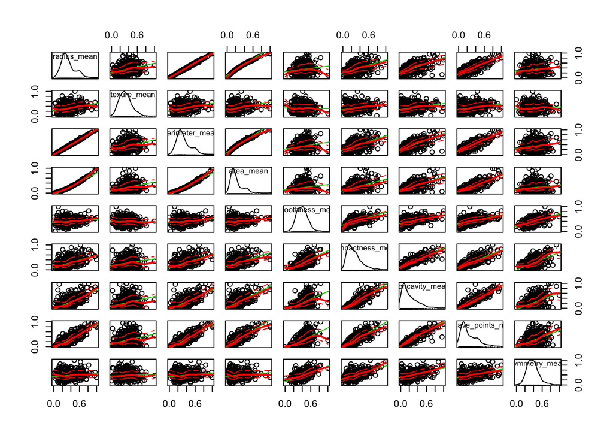

```r
scatterplotMatrix(cancer.normalized[,1:9])
```

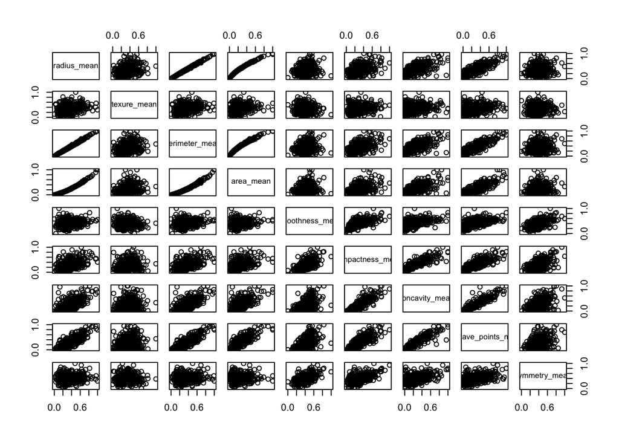

```r
pairs(cancer.normalized[,1:9])
```

```r
#split my data into training part and testing part
cancer.train <- cancer.normalized[1:500,]
cancer.test <- cancer.normalized[501:569,]
cancer.train.target <- cancer_data[1:500,2]
cancer.test.target <- cancer_data[501:569,2]

#using LDA
cancer.lda <- lda(cancer.train.target~., data=cancer.train)
cancer.lda
```

```
## Call:
## lda(cancer.train.target ~ ., data = cancer.train)
##
## Prior probabilities of groups:
##     B     M
## 0.636 0.364
##
## Group means:
##   radius_mean texure_mean perimeter_mean area_mean smoothness_mean
## B   0.2434860   0.2761872      0.2359636 0.1347901       0.3571072
## M   0.5055647   0.4008964      0.5039924 0.3632951       0.4498223
##   compactness_mean concavity_mean concave_points_mean symmetry_mean
## B        0.1863355      0.1088961           0.1272673     0.3440347
## M        0.3850160      0.3779686           0.4438157     0.4381452
##   fractal_dimension_mean  radius_SE texure_SE perimeter_SE    area_SE
## B              0.2738512 0.06239135 0.1843959   0.05853974 0.02673766
## M              0.2617620 0.18464782 0.1898994   0.17324482 0.12762002
##   smoothness_SE compactness_SE concavity_SE concave_points_SE symmetry_SE
## B     0.1864199      0.1464068   0.06717828         0.1874782   0.1781531
## M     0.1705850      0.2266939   0.10533217         0.2886295   0.1744843
##   fractal_dimension_SE radius_worst texure_worst perimeter_worst
## B           0.09686564    0.1932006    0.3044808       0.1816268
## M           0.10850162    0.4777288    0.4589538       0.4604193
##   area_worst smoothness_worst compactness_worst concavity_worst
## B 0.09146795        0.3528008         0.1513911       0.1341106
## M 0.31102725        0.4781504         0.3347875       0.3569361
##   concave_points_worst symmetry_worst fractal_dimension_worst
## B            0.2558656      0.2249001               0.1619571
## M            0.6317705      0.3269897               0.2332296
##
## Coefficients of linear discriminants:
##                                 LD1
## radius_mean             -27.0093131
## texure_mean               0.5515401
## perimeter_mean           20.7218668
## area_mean                 5.0222555
## smoothness_mean           0.5375216
## compactness_mean         -7.0712882
## concavity_mean            2.0040579
## concave_points_mean       2.7833787
## symmetry_mean            -0.1791856
## fractal_dimension_mean   -0.0956335
## radius_SE                 5.8758980
## texure_SE                -0.6438832
## perimeter_SE             -1.1641631
## area_SE                  -3.2373755
## smoothness_SE             2.5972188
## compactness_SE            0.6546591
## concavity_SE             -6.9505631
## concave_points_SE         3.4254229
## symmetry_SE              -0.2616661
## fractal_dimension_SE     -1.2111637
## radius_worst             29.7682102
## texure_worst              1.6442592
## perimeter_worst          -5.3760345
## area_worst              -20.4958686
## smoothness_worst          0.1633950
## compactness_worst        -0.5936693
## concavity_worst           2.5707552
## concave_points_worst      0.2113588
## symmetry_worst            2.6803196
## fractal_dimension_worst   3.8892750
```

## Does the number of predictor variables for LDA make a difference? Try for a range of models using differing numbers of predictor variables.

```r
#use whole variables(30)
cancer.whole.var <- cancer.normalized[,1:30]

#split the data
cancer.whole.train <- cancer.whole.var[1:500,]
cancer.whole.test <- cancer.whole.var[501:569,]
cancer.whole.train.target <- cancer_data[1:500,2]
cancer.whole.test.target <- cancer_data[501:569,2]

#using LDA
cancer.whole.lda <- lda(cancer.whole.train.target~., data=cancer.whole.train)
cancer.whole.lda.pred <- predict(cancer.whole.lda, newdata = cancer.whole.test)
whole.cm <- table(cancer.whole.lda.pred$class, cancer.whole.test.target)


###########################
#use half of the variables(15)
cancer.half.var <- cancer.normalized [,1:15]

#split the data
cancer.half.train <- cancer.half.var[1:500,]
cancer.half.test <- cancer.half.var[501:569,]
cancer.half.train.target <- cancer_data[1:500,2]
cancer.half.test.target <- cancer_data[501:569,2]

#using LDA
cancer.half.lda <- lda(cancer.half.train.target~., data=cancer.half.train)
cancer.half.lda.pred <- predict(cancer.half.lda, newdata = cancer.half.test)
half.cm <- table(cancer.half.lda.pred$class, cancer.half.test.target)

###########################
#use ten variables
cancer.ten.var <- cancer.normalized[,1:10]

#split the data
cancer.ten.train <- cancer.ten.var[1:500,]
cancer.ten.test <- cancer.ten.var[501:569,]
cancer.ten.train.target <- cancer_data[1:500,2]
cancer.ten.test.target <- cancer_data[501:569,2]

#using LDA
cancer.ten.lda <- lda(cancer.ten.train.target~., data=cancer.ten.train)
cancer.ten.lda.pred <- predict(cancer.ten.lda, newdata = cancer.ten.test)
ten.cm <- table(cancer.ten.lda.pred$class, cancer.ten.test.target)

###########################
#use five variables
cancer.five.var<- cancer.normalized[,1:5]

#split the data
cancer.five.train <- cancer.five.var[1:500,]
cancer.five.test <- cancer.five.var[501:569,]
cancer.five.train.target <- cancer_data[1:500,2]
cancer.five.test.target <- cancer_data[501:569,2]

#using LDA
cancer.five.lda <- lda(cancer.five.train.target~., data=cancer.five.train)
cancer.five.lda.pred <- predict(cancer.five.lda, newdata = cancer.five.test)
five.cm <- table(cancer.five.lda.pred$class, cancer.five.test.target)

###########################
#use two variables
cancer.two.var<- cancer.normalized[,1:2]

#split the data
cancer.two.train <- cancer.two.var[1:500,]
cancer.two.test <- cancer.two.var[501:569,]
cancer.two.train.target <- cancer_data[1:500,2]
cancer.two.test.target <- cancer_data[501:569,2]

#using LDA
cancer.two.lda <- lda(cancer.two.train.target~., data=cancer.two.train)
cancer.two.lda.pred <- predict(cancer.two.lda, newdata = cancer.two.test)
two.cm <- table(cancer.two.lda.pred$class, cancer.two.test.target)

########################
#comparing models using differing numbers of predictor variables
whole.cm
```

```
##    cancer.whole.test.target
##      B  M
##   B 39  4
##   M  0 26
```

```r
half.cm
```

```
##    cancer.half.test.target
##      B  M
##   B 39  6
##   M  0 24
```

```r
ten.cm
```

```
##    cancer.ten.test.target
##      B  M
##   B 39  5
##   M  0 25
```

```r
five.cm
```

```
##    cancer.five.test.target
##      B  M
##   B 37  6
##   M  2 24
```

```r
two.cm
```

```
##    cancer.two.test.target
##      B  M
##   B 38 11
##   M  1 19
```

When I use all variables, there are four misclassifications. When I use half of the variables, there are six misclassifications. When I use ten variables, there are five misclassificatoins. When I use five variables, there are eight misclassifications. When I use first two variables, there are 12 misclassifications. It is easy to find that different variables will have different perfomance. So the number of predictor variables for LDA makes a difference.

If I want to got the best k of dimensions of the new feature subspae, it need to compute eigenvectors and collect them.

## What determines the number of linear discriminants in LDA.

The number of classes determines the number of linear discriminants in LDA. The LDA will find at most k-1 linear discriminants. In my data set, I have two classes, so it has one linear discriminant.

## Does scaling, normalization or leaving the data unscaled make a difference for LDA?

```r
#normalized data
normalize <- function(x){
  return((x-min(x))/(max(x)-min(x)))
}
cancer.normalized <- as.data.frame(lapply(cancer_data[,3:32],normalize))

#split my data into training part and testing part
cancer.normalized.train <- cancer.normalized[1:500,]
cancer.normalized.test <- cancer.normalized[501:569,]
cancer.normalized.train.target <- cancer_data[1:500,2]
cancer.normalized.test.target <- cancer_data[501:569,2]

#LDA using normalized data
cancer.normalized.lda <- lda(cancer.normalized.train.target~., data=cancer.normalized.train)
cancer.normalized.lda.pred <- predict(cancer.normalized.lda, newdata = cancer.normalized.test)
normalized.cm <- table(cancer.normalized.lda.pred$class, cancer.normalized.test.target)

##################
#scaling data
cancer.scaled <- as.data.frame(lapply(cancer_data[,3:32], scale))

#split my data into training part and testing part
cancer.scaled.train <- cancer.scaled[1:500,]
cancer.scaled.test <- cancer.scaled[501:569,]
cancer.scaled.train.target <- cancer_data[1:500,2]
cancer.scaled.test.target <- cancer_data[501:569,2]

#LDA using scaling data
cancer.scaled.lda <- lda(cancer.scaled.train.target~., data=cancer.scaled.train)
cancer.scaled.lda.pred <- predict(cancer.scaled.lda, newdata = cancer.scaled.test)
scaled.cm <- table(cancer.scaled.lda.pred$class, cancer.scaled.test.target)


###################
#unscaled data
cancer.unscaled <- cancer_data[,3:32]

#split my data into training part and testing part
cancer.unscaled.train <- cancer.unscaled[1:500,]
cancer.unscaled.test <- cancer.unscaled[501:569,]
cancer.unscaled.train.target <- cancer_data[1:500,2]
cancer.unscaled.test.target <- cancer_data[501:569,2]

#LDA using unscaling data
cancer.unscaled.lda <- lda(cancer.unscaled.train.target~., data=cancer.unscaled.train)
cancer.unscaled.lda.pred <- predict(cancer.unscaled.lda, newdata = cancer.unscaled.test)
unscaled.cm <- table(cancer.unscaled.lda.pred$class, cancer.unscaled.test.target)

##################
#comparing models using differing type of data
normalized.cm
```

```
##    cancer.normalized.test.target
##      B  M
##   B 39  4
##   M  0 26
```

```r
scaled.cm
```

```
##    cancer.scaled.test.target
##      B  M
##   B 39  4
##   M  0 26
```

```r
unscaled.cm
```

```
##    cancer.unscaled.test.target
##      B  M
##   B 39  4
##   M  0 26
```